# Using fdaMixedRTMB: boundary-value models, diagnostics, and marginal means

`fdaMixedRTMB` fits operator-based functional mixed models where each observed curve is represented on a common time grid. This vignette uses the packaged beer-tracker data to show the typical workflow:

1. We turn event-level records into cumulative and weekly trajectory data.
2. Fit a boundary-value model with `fdaLm_rtmb()`.
3. Inspect the fitted object with package methods.
4. Use diagnostic plots.
5. Use `emmeans` for the boundary-value regression.
6. Extract fitted curves for plotting or downstream summaries.

```r
library(fdaMixedRTMB)
library(emmeans)
library(tidyverse)
library(lubridate)

old_theme <- theme_set(theme_minimal(base_size = 11))

sex_cols <- c(F = "#D55E00", M = "#0072B2")
```

## Prepare Beer-Tracker Data

The example data are event records: one row per logged beer. A functional response needs one row per subject and time point, so the first step is to aggregate to daily counts and fill missing subject-day combinations with zero.

```r
beer_file <- system.file("examples", "dailybeers.csv", package = "fdaMixedRTMB")

if (!nzchar(beer_file)) {
  beer_file <- file.path("..", "inst", "examples", "dailybeers.csv")
}

sex_lookup <- tibble(
  navn = c(
    "Mille", "Milla", "Augusta", "Lise", "Frigg",
    "Baldur", "Julle", "Malthe", "Nikolai", "William"
  ),
  sex = c(rep("F", 5), rep("M", 5))
)

beer_raw <- read_csv(beer_file, show_col_types = FALSE) |>
  mutate(
    timestamp = as.POSIXct(
      tid,
      format = "%d/%m/%Y %H.%M.%S",
      tz = "UTC"
    ),
    date = as_date(timestamp),
    beer = str_replace(as.character(antal), ",", "."),
    beer = as.numeric(beer),
    beer = replace_na(beer, 1)
  ) |>
  select(navn, date, beer) |>
  left_join(sex_lookup, by = "navn")

range(beer_raw$date)
```

```
#> [1] "2026-01-01" "2026-05-26"
```

```r
beer_raw |>
  count(navn)
```

```
#> # A tibble: 10 × 2
#>    navn        n
#>    <chr>   <int>
#>  1 Augusta    49
#>  2 Baldur     19
#>  3 Frigg      84
#>  4 Julle      68
#>  5 Lise       49
#>  6 Malthe     32
#>  7 Milla      15
#>  8 Mille      76
#>  9 Nikolai    82
#> 10 William    53
```

The names are anonymized before modeling. `design` data frames in `fdaMixedRTMB` are curve-level data frames: they contain one row per curve and the covariates that are constant for that curve. The raw log has no beer entries after May 26, but the observation window runs through May 28, so the daily grid below explicitly includes May 27 and May 28 as zero-count days.

```r
last_beer_date <- max(beer_raw$date, na.rm = TRUE)
analysis_year <- year(last_beer_date)

analysis_start <- ymd(paste0(analysis_year, "-01-01"))
analysis_end <- max(
  last_beer_date,
  ymd(paste0(year(last_beer_date), "-", month(last_beer_date), "-28"))
)

months_ordered <- month.name[seq_len(month(analysis_end))]
n_days_month <- min(28L, day(analysis_end))

c(
  last_logged_beer = as.character(last_beer_date),
  analysis_end = as.character(analysis_end)
)
```

```
#> last_logged_beer     analysis_end
#>     "2026-05-26"     "2026-05-28"
```

```r
date_grid <- tibble(
  date = seq(analysis_start, analysis_end, by = "day")
) |>
  mutate(
    day = row_number(),
    month_num = month(date),
    month_name = factor(month.name[month_num], levels = month.name),
    day_within_month = day(date)
  )

subject_lookup <- beer_raw |>
  distinct(navn, sex) |>
  arrange(navn) |>
  mutate(
    subject = row_number(),
    name = factor(paste("Friend", subject), levels = paste("Friend", subject)),
    sex = factor(sex, levels = c("F", "M"))
  )

daily_totals <- beer_raw |>
  group_by(navn, sex, date) |>
  summarise(beer = sum(beer), .groups = "drop")

beer_daily <- subject_lookup |>
  crossing(date_grid) |>
  left_join(daily_totals, by = c("navn", "sex", "date")) |>
  mutate(beer = replace_na(beer, 0)) |>
  arrange(subject, day) |>
  group_by(subject) |>
  mutate(beer_gain = cumsum(beer)) |>
  ungroup()

beer_daily |>
  select(name, sex, date, day, beer, beer_gain) |>
  head()
```

```
#> # A tibble: 6 × 6
#>   name     sex   date         day  beer beer_gain
#>   <fct>    <chr> <date>     <int> <dbl>     <dbl>
#> 1 Friend 1 F     2026-01-01     1     0         0
#> 2 Friend 1 F     2026-01-02     2     0         0
#> 3 Friend 1 F     2026-01-03     3     0         0
#> 4 Friend 1 F     2026-01-04     4     0         0
#> 5 Friend 1 F     2026-01-05     5     0         0
#> 6 Friend 1 F     2026-01-06     6     0         0
```

```r
beer_daily |>
  filter(date >= analysis_end - days(1)) |>
  group_by(date) |>
  summarise(beer = sum(beer), .groups = "drop")
```

```
#> # A tibble: 2 × 2
#>   date        beer
#>   <date>     <dbl>
#> 1 2026-05-27     0
#> 2 2026-05-28     0
```

### Full-Period Curves

Full-period curves accumulate beer gains from the first analysis day through the last available day. The right endpoint of such a curve is the subject’s total beer gain over the full tracker period.

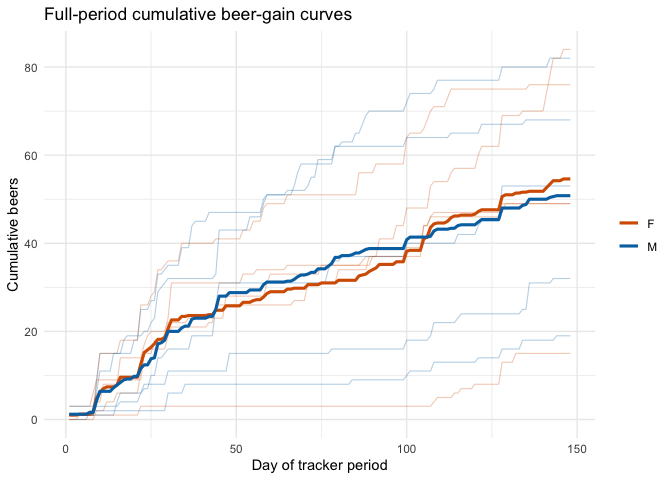

```r
full_period_df <- beer_daily |>
  mutate(
    time = day,
    y = beer_gain,
    curve = name
  )

full_curve_meta <- full_period_df |>
  distinct(curve, subject, name, sex) |>
  arrange(subject)

ggplot(full_period_df, aes(time, y, colour = sex)) +
  geom_line(aes(group = name), alpha = 0.3, linewidth = 0.4) +
  stat_summary(aes(group = sex), fun = mean, geom = "line", linewidth = 1.1) +
  scale_colour_manual(values = sex_cols) +
  labs(
    title = "Full-period cumulative beer-gain curves",
    x = "Day of tracker period",
    y = "Cumulative beers",
    colour = NULL
  )
```

A full-period model uses the same interface. For example, the endpoint boundary derivative could be modeled by sex:

```r
fit_full <- fdaLm_rtmb(
  y | curve ~ 0,
  data = full_period_df,
  design = full_curve_meta,
  boundary_formula = ~ sex,
  boundary_value = TRUE,
  operator = operator_laplace(),
  right_boundary = right_boundary_operator_k1(alpha = c(0, 1)),
  time_variable = "time"
)
```

### Monthly Curves

Monthly curves reset the cumulative sum at the beginning of each month. To put all months on the same time grid, this vignette uses the common number of available days, capped at 28.

```r
beer_monthly_df <- beer_daily |>
  filter(
    month_name %in% months_ordered,
    day_within_month <= n_days_month
  ) |>
  arrange(subject, month_num, day_within_month) |>
  group_by(subject, month_num) |>
  mutate(monthly_cumsum = cumsum(beer)) |>
  ungroup() |>
  mutate(
    month_name = factor(as.character(month_name), levels = months_ordered),
    curve = paste(name, month_name, sep = ": ")
  )

curve_meta <- beer_monthly_df |>
  distinct(curve, subject, name, sex, month_name, month_num) |>
  arrange(subject, month_num) |>
  mutate(
    curve = factor(curve, levels = curve),
    name = factor(name, levels = levels(subject_lookup$name)),
    sex = factor(sex, levels = c("F", "M")),
    month_name = factor(month_name, levels = months_ordered)
  )

beer_monthly_df <- beer_monthly_df |>
  mutate(curve = factor(curve, levels = levels(curve_meta$curve)))

beer_monthly_df |>
  select(name, month_name, day_within_month, beer, monthly_cumsum, curve) |>
  head()
```

```
#> # A tibble: 6 × 6
#>   name     month_name day_within_month  beer monthly_cumsum curve
#>   <fct>    <fct>                 <int> <dbl>          <dbl> <fct>
#> 1 Friend 1 January                   1     0              0 Friend 1: January
#> 2 Friend 1 January                   2     0              0 Friend 1: January
#> 3 Friend 1 January                   3     0              0 Friend 1: January
#> 4 Friend 1 January                   4     0              0 Friend 1: January
#> 5 Friend 1 January                   5     0              0 Friend 1: January
#> 6 Friend 1 January                   6     0              0 Friend 1: January
```

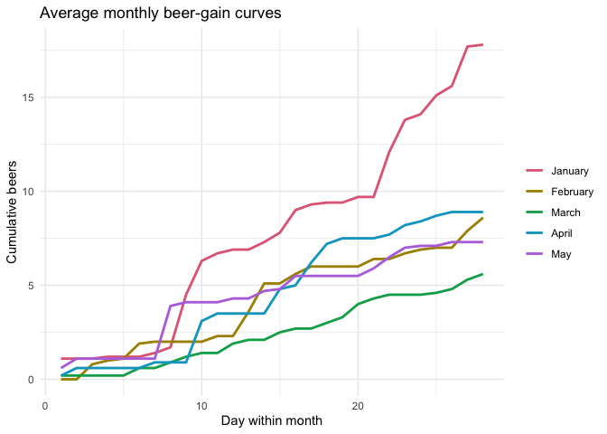

```r
monthly_means <- beer_monthly_df |>
  group_by(month_name, day_within_month) |>
  summarise(monthly_cumsum = mean(monthly_cumsum), .groups = "drop")

month_cols <- setNames(
  grDevices::hcl.colors(length(months_ordered), "Dark 3"),
  months_ordered
)

ggplot(monthly_means, aes(day_within_month, monthly_cumsum, colour = month_name)) +
  geom_line(linewidth = 1) +
  scale_colour_manual(values = month_cols) +
  labs(
    title = "Average monthly beer-gain curves",
    x = "Day within month",
    y = "Cumulative beers",
    colour = NULL
  )
```

## Fit a Boundary-Value Model

The model below uses monthly cumulative beer gains as the response. For a faster and more readable vignette, the fit uses four anonymized participants; the data-preparation code above created the full set of monthly curves.

```r
model_subjects <- levels(subject_lookup$name)[1:4]

curve_meta_model <- curve_meta |>
  filter(name %in% model_subjects) |>
  mutate(curve = factor(as.character(curve), levels = as.character(curve)))

beer_monthly_model <- beer_monthly_df |>
  filter(name %in% model_subjects) |>
  mutate(curve = factor(as.character(curve), levels = levels(curve_meta_model$curve)))

c(
  observations = nrow(beer_monthly_model),
  curves = nlevels(beer_monthly_model$curve),
  days_per_curve = n_days_month
)
```

```
#>   observations         curves days_per_curve
#>            560             20             28
```

```r
fit <- fdaLm_rtmb(
  monthly_cumsum | curve ~ 0,
  data = beer_monthly_model,
  design = curve_meta_model,
  boundary_formula = ~ month_name,
  boundary_value = TRUE,
  operator = operator_laplace(),
  right_boundary = right_boundary_operator_k1(alpha = c(0, 1)),
  time_variable = "day_within_month"
)
```

The main arguments are:

- `monthly_cumsum | curve ~ 0`: the response is `monthly_cumsum`, and `curve` identifies the functional curve. The fixed-effect part is `0` because this example puts the month effect in the boundary-value regression.
- `boundary_value = TRUE`: estimate a nonzero right-boundary value.
- `boundary_formula = ~ month_name`: model the curve-level boundary value as a function of month.
- `right_boundary = right_boundary_operator_k1(alpha = c(0, 1))`: define the right boundary operator as endpoint derivative, so the fitted `rho` is the month-end derivative.
- `operator = operator_laplace()`: use the K.order = 1 pure Laplace operator `L f = -lambda_d2 f''`. The shifted operator is available via `operator_k1(lambda_start = c(1, 1))`.

## Inspect the Fitted Model

The fitted object has ordinary R methods for printing, summarizing, coefficients, predictions, residuals, log likelihoods, and model dimensions.

```r
fit
```

```
#> boundary_value_fit
#>   converged: TRUE
#>   curves: 20   points/curve: 28
#>   right operator: 0 * X(b) + 1 * X'(b) = rho
#>   boundary model: rho ~ month_name
#>   operator: L f = -lambda_d2 * f''
#>   tau: 0.75205  lambda_d2: 0.58182  lambda_level: 0.00000  kappa: 0.00000
#>   sigma2: 0.43756
#>   rho by boundary model:
#>  month_name=January month_name=February    month_name=March    month_name=April
#>             0.68093             0.26929             0.15635             0.33469
#>      month_name=May
#>             0.33949
```

```r
summary(fit)
```

```
#> Boundary-value fit summary
#>   converged: TRUE
#>   logLik: -824.73461
#>   right operator: 0 * X(b) + 1 * X'(b) = rho
#>   boundary model: rho ~ month_name
#>   operator: L f = -lambda_d2 * f''
#>     tau = 0.75205  lambda_d2 = 0.58182  lambda_level = 0.00000  kappa = 0.00000
#>   noise: sigma2 = 0.43756 sigma_u2 = 0.00000
#>
#> Boundary-value coefficients
#>        rho_(Intercept) rho_month_nameFebruary    rho_month_nameMarch
#>                0.68093               -0.41164               -0.52459
#>    rho_month_nameApril      rho_month_nameMay
#>               -0.34625               -0.34144
#>
#> Boundary-model rho
#>  month_name=January month_name=February    month_name=March    month_name=April
#>             0.68093             0.26929             0.15635             0.33469
#>      month_name=May
#>             0.33949
#>
#> Curve-specific rho
#>  Friend 1: January Friend 1: February    Friend 1: March    Friend 1: April
#>            0.68093            0.26929            0.15635            0.33469
#>      Friend 1: May  Friend 2: January Friend 2: February    Friend 2: March
#>            0.33949            0.68093            0.26929            0.15635
#>    Friend 2: April      Friend 2: May  Friend 3: January Friend 3: February
#>            0.33469            0.33949            0.68093            0.26929
#>    Friend 3: March    Friend 3: April      Friend 3: May  Friend 4: January
#>            0.15635            0.33469            0.33949            0.68093
#> Friend 4: February    Friend 4: March    Friend 4: April      Friend 4: May
#>            0.26929            0.15635            0.33469            0.33949
#>
#> Homogeneous serial boundary check
#>  Friend 1: January Friend 1: February    Friend 1: March    Friend 1: April
#>           -0.19118            0.71431           -0.05869           -0.12565
#>      Friend 1: May  Friend 2: January Friend 2: February    Friend 2: March
#>           -0.12745           -0.25563           -0.10109           -0.05298
#>    Friend 2: April      Friend 2: May  Friend 3: January Friend 3: February
#>           -0.12564           -0.12587           -0.24546           -0.09531
#>    Friend 3: March    Friend 3: April      Friend 3: May  Friend 4: January
#>            0.21311           -0.12320           -0.08369            0.20675
#> Friend 4: February    Friend 4: March    Friend 4: April      Friend 4: May
#>            0.39575           -0.05866           -0.12521           -0.12745
```

```r
coef(fit, component = "boundary")
```

```
#>        rho_(Intercept) rho_month_nameFebruary    rho_month_nameMarch
#>              0.6809336             -0.4116431             -0.5245866
#>    rho_month_nameApril      rho_month_nameMay
#>             -0.3462464             -0.3414422
```

```r
coef(fit, component = "rho")
```

```
#>  Friend 1: January Friend 1: February    Friend 1: March    Friend 1: April
#>          0.6809336          0.2692905          0.1563470          0.3346872
#>      Friend 1: May  Friend 2: January Friend 2: February    Friend 2: March
#>          0.3394914          0.6809336          0.2692905          0.1563470
#>    Friend 2: April      Friend 2: May  Friend 3: January Friend 3: February
#>          0.3346872          0.3394914          0.6809336          0.2692905
#>    Friend 3: March    Friend 3: April      Friend 3: May  Friend 4: January
#>          0.1563470          0.3346872          0.3394914          0.6809336
#> Friend 4: February    Friend 4: March    Friend 4: April      Friend 4: May
#>          0.2692905          0.1563470          0.3346872          0.3394914
```

```r
coef(fit, component = "variance")
```

```
#>       tau    sigma2  sigma_u2
#> 0.7520501 0.4375565 0.0000000
```

`component = "boundary"` gives the coefficients of the boundary-value regression. `component = "rho"` returns the fitted curve-specific boundary values.

## Plot Diagnostics

The S3 diagnostic method is available as `plot(fit, which = c("fit", "residual", "rho"))`. The vignette below builds the same common diagnostics with `ggplot2` so the plot style is consistent:

- `"fit"`: observed values against fitted values,
- `"residual"`: residuals against fitted values, and
- `"rho"`: estimated curve-specific right-boundary values.

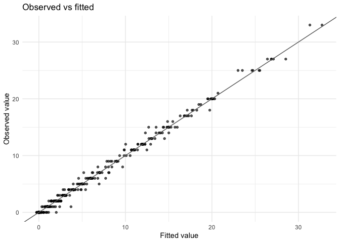

```r
diagnostic_df <- tibble(
  observed = fit$data$y,
  fitted = as.numeric(predict(fit, type = "response")),
  residual = as.numeric(residuals(fit))
)

rho_df <- tibble(
  curve = names(coef(fit, component = "rho")),
  rho = as.numeric(coef(fit, component = "rho"))
) |>
  mutate(curve = factor(curve, levels = curve))

ggplot(diagnostic_df, aes(fitted, observed)) +
  geom_point(alpha = 0.65, size = 1.2) +
  geom_abline(slope = 1, intercept = 0, colour = "grey40") +
  labs(
    title = "Observed vs fitted",
    x = "Fitted value",
    y = "Observed value"
  )
```

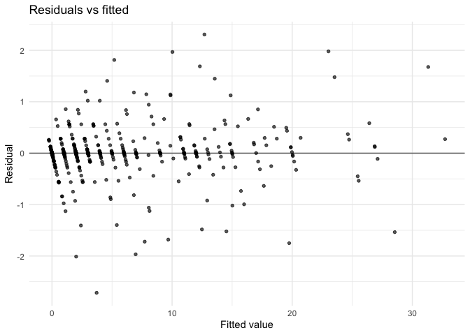

```r
ggplot(diagnostic_df, aes(fitted, residual)) +
  geom_hline(yintercept = 0, colour = "grey40") +
  geom_point(alpha = 0.65, size = 1.2) +
  labs(
    title = "Residuals vs fitted",
    x = "Fitted value",
    y = "Residual"
  )
```

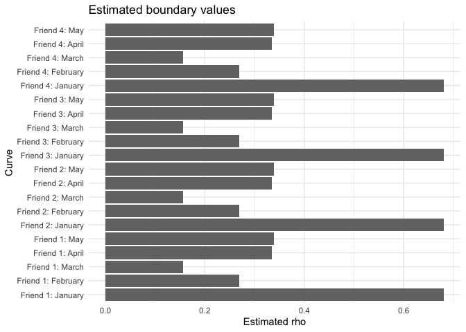

```r
ggplot(rho_df, aes(curve, rho)) +
  geom_col(fill = "grey45") +
  coord_flip() +
  labs(
    title = "Estimated boundary values",
    x = "Curve",
    y = "Estimated rho"
  )
```

The `"boundary"` panel is also useful: it checks the right boundary operator on the homogeneous serial effect. For a well-behaved boundary-value decomposition, this quantity should be close to zero relative to the scale of `rho`.

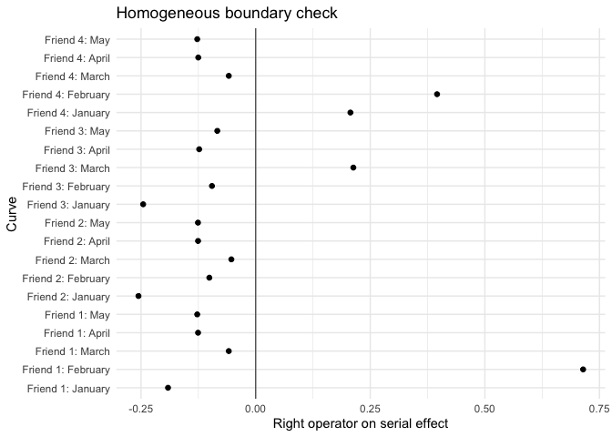

```r
boundary_check_df <- tibble(
  curve = names(fit$right_boundary_serial_operator),
  right_operator = as.numeric(fit$right_boundary_serial_operator)
) |>
  mutate(curve = factor(curve, levels = curve))

ggplot(boundary_check_df, aes(curve, right_operator)) +
  geom_hline(yintercept = 0, colour = "grey40") +
  geom_point(size = 1.6) +
  coord_flip() +
  labs(
    title = "Homogeneous boundary check",
    x = "Curve",
    y = "Right operator on serial effect"
  )
```

## Use emmeans

`fdaMixedRTMB` provides `emmeans` support for both ordinary fixed effects and the boundary-value regression. Here we ask for marginal means of `month_name` in `mode = "boundary"`, which targets the fitted `rho ~ month_name` model.

```r
emm_month <- emmeans(fit, ~ month_name, mode = "boundary")
emm_month
```

```
#>  month_name emmean     SE  df lower.CL upper.CL
#>  January     0.681 0.0778 555  0.52802    0.834
#>  February    0.269 0.0778 555  0.11638    0.422
#>  March       0.156 0.0778 555  0.00343    0.309
#>  April       0.335 0.0778 555  0.18177    0.488
#>  May         0.339 0.0778 555  0.18658    0.492
#>
#> Confidence level used: 0.95
```

```r
pairs(emm_month)
```

```
#>  contrast           estimate   SE  df t.ratio p.value
#>  January - February   0.4116 0.11 555   3.739  0.0019
#>  January - March      0.5246 0.11 555   4.765 <0.0001
#>  January - April      0.3462 0.11 555   3.145  0.0150
#>  January - May        0.3414 0.11 555   3.101  0.0172
#>  February - March     0.1129 0.11 555   1.026  0.8434
#>  February - April    -0.0654 0.11 555  -0.594  0.9760
#>  February - May      -0.0702 0.11 555  -0.638  0.9689
#>  March - April       -0.1783 0.11 555  -1.620  0.4852
#>  March - May         -0.1831 0.11 555  -1.664  0.4575
#>  April - May         -0.0048 0.11 555  -0.044  1.0000
#>
#> P value adjustment: tukey method for comparing a family of 5 estimates
```

Because the right boundary is `alpha = c(0, 1)`, these marginal means are estimated endpoint derivatives. If the right boundary were `alpha = c(1, 0)`, the same `emmeans()` call would summarize the month-end cumulative beer gains instead.

## Extract Fitted Curves

Use `predict()` and `residuals()` to recover fitted values and model components on the original curve grid. The returned vectors follow the internal curve-time ordering, so the data are sorted by `curve` and time before adding them.

```r
fitted_curves <- beer_monthly_model |>
  arrange(curve, day_within_month) |>
  mutate(
    fitted = as.numeric(predict(fit, type = "response")),
    boundary_effect = as.numeric(predict(fit, type = "boundary")),
    serial_effect = as.numeric(predict(fit, type = "serial")),
    residual = as.numeric(residuals(fit))
  )

fitted_curves |>
  select(
    name, month_name, day_within_month, monthly_cumsum,
    fitted, boundary_effect, serial_effect, residual
  ) |>
  head()
```

```
#> # A tibble: 6 × 8
#>   name     month_name day_within_month monthly_cumsum    fitted boundary_effect
#>   <fct>    <fct>                 <int>          <dbl>     <dbl>           <dbl>
#> 1 Friend 1 January                   1              0 -0.259              0
#> 2 Friend 1 January                   2              0 -0.0643             0.681
#> 3 Friend 1 January                   3              0 -0.0151             1.36
#> 4 Friend 1 January                   4              0 -0.000837           2.04
#> 5 Friend 1 January                   5              0  0.0110             2.72
#> 6 Friend 1 January                   6              0  0.0434             3.40
#> # ℹ 2 more variables: serial_effect <dbl>, residual <dbl>
```

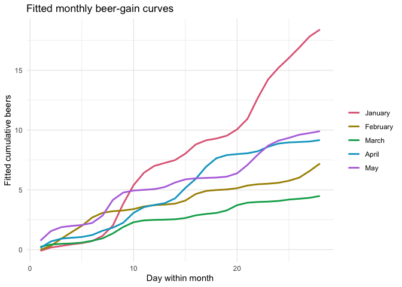

```r
fitted_month_means <- fitted_curves |>
  group_by(month_name, day_within_month) |>
  summarise(fitted = mean(fitted), .groups = "drop")

ggplot(fitted_month_means, aes(day_within_month, fitted, colour = month_name)) +
  geom_line(linewidth = 1) +
  scale_colour_manual(values = month_cols) +
  labs(
    title = "Fitted monthly beer-gain curves",
    x = "Day within month",
    y = "Fitted cumulative beers",
    colour = NULL
  )
```

## Weekly Trajectories Without Cumulative Sums

The cumulative curves are useful when the scientific question is about total gain by the end of a period. A different question is whether the weekly numbers themselves change over time. In that case each curve is one person’s tracker-week beer totals, the time grid is week number, and the response is `weekly_beers` rather than an accumulated total. Weeks are consecutive 7-day blocks anchored at January 1. The observation window ends on May 28, which creates one trailing zero-only day; that day is folded into the final tracker week so the last plotted point is the May 21-28 week rather than an artificial zero-only week.

For non-cumulative weekly counts, the endpoint value is just the beer count in the final modeled week. The endpoint derivative is more useful: it estimates the local trend at the end of the observed period, in weekly beers per week. This example therefore uses `right_boundary = c(0, 1)` and a boundary regression `rho ~ sex`.

```r
beer_weekly_daily <- beer_daily |>
  mutate(raw_week_num = ((day - 1L) %/% 7L) + 1L)

last_raw_week <- max(beer_weekly_daily$raw_week_num)

last_raw_week_total <- beer_weekly_daily |>
  filter(raw_week_num == last_raw_week) |>
  summarise(total = sum(beer), .groups = "drop") |>
  pull(total)

beer_weekly_daily <- beer_weekly_daily |>
  mutate(
    week_num = if_else(
      last_raw_week_total == 0 & last_raw_week > 1L & raw_week_num == last_raw_week,
      last_raw_week - 1L,
      raw_week_num
    )
  )

n_weeks <- max(beer_weekly_daily$week_num)

beer_weekly_df <- beer_weekly_daily |>
  group_by(subject, name, sex, week_num) |>
  summarise(weekly_beers = sum(beer), .groups = "drop") |>
  arrange(subject, week_num) |>
  mutate(
    week_index = week_num - 1L,
    week_label = factor(
      paste("Week", week_index),
      levels = paste("Week", seq_len(n_weeks) - 1L)
    ),
    curve = name
  )

weekly_curve_meta <- beer_weekly_df |>
  distinct(curve, subject, name, sex) |>
  arrange(subject) |>
  mutate(
    curve = factor(curve, levels = curve),
    name = factor(name, levels = levels(subject_lookup$name)),
    sex = factor(sex, levels = c("F", "M"))
  )

beer_weekly_df <- beer_weekly_df |>
  mutate(curve = factor(curve, levels = levels(weekly_curve_meta$curve)))

beer_weekly_df |>
  select(name, sex, week_index, week_label, weekly_beers, curve) |>
  head()
```

```
#> # A tibble: 6 × 6
#>   name     sex   week_index week_label weekly_beers curve
#>   <fct>    <chr>      <int> <fct>             <dbl> <fct>
#> 1 Friend 1 F              0 Week 0                0 Friend 1
#> 2 Friend 1 F              1 Week 1                4 Friend 1
#> 3 Friend 1 F              2 Week 2                2 Friend 1
#> 4 Friend 1 F              3 Week 3               12 Friend 1
#> 5 Friend 1 F              4 Week 4                4 Friend 1
#> 6 Friend 1 F              5 Week 5                1 Friend 1
```

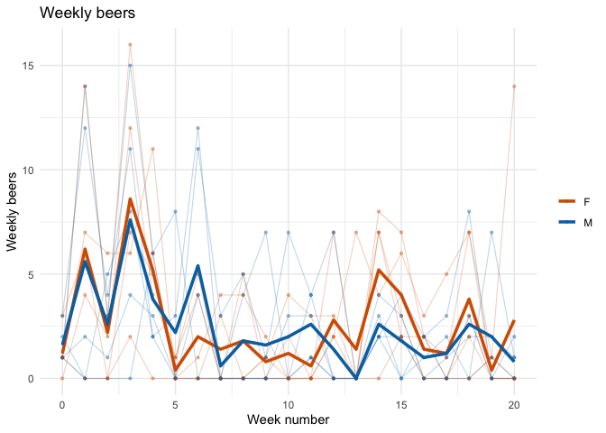

```r
ggplot(beer_weekly_df, aes(week_index, weekly_beers, colour = sex)) +
  geom_line(aes(group = name), alpha = 0.25, linewidth = 0.4) +
  geom_point(aes(group = name), alpha = 0.35, size = 0.8) +
  stat_summary(aes(group = sex), fun = mean, geom = "line", linewidth = 1.25) +
  scale_colour_manual(values = sex_cols) +
  scale_x_continuous(breaks = seq(0, n_weeks - 1L, by = 5)) +
  labs(
    title = "Weekly beers",
    x = "Week number",
    y = "Weekly beers",
    colour = NULL
  )
```

```r
fit_weekly <- fdaLm_rtmb(
  weekly_beers | curve ~ 0,
  data = beer_weekly_df,
  design = weekly_curve_meta,
  boundary_formula = ~ sex,
  boundary_value = TRUE,
  operator = operator_laplace(),
  right_boundary = right_boundary_operator_k1(alpha = c(0, 1)),
  time_variable = "week_index"
)

c(
  observations = nrow(beer_weekly_df),
  curves = nlevels(beer_weekly_df$curve),
  weeks_per_curve = n_distinct(beer_weekly_df$week_num),
  converged = fit_weekly$converged
)
```

```
#>    observations          curves weeks_per_curve       converged
#>             210              10              21               1
```

The boundary coefficients and marginal means now describe sex differences in the right-end derivative of the weekly-number trajectory. Because the right boundary is `alpha = c(0, 1)`, `rho` is the fitted endpoint slope rather than the fitted number of beers in the final week.

```r
coef(fit_weekly, component = "boundary")
```

```
#> rho_(Intercept)        rho_sexM
#>      0.07778136     -0.04165224
```

```r
coef(fit_weekly, component = "rho")
```

```
#>   Friend 1   Friend 2   Friend 3   Friend 4   Friend 5   Friend 6   Friend 7
#> 0.07778136 0.03612912 0.07778136 0.03612912 0.07778136 0.03612912 0.07778136
#>   Friend 8   Friend 9  Friend 10
#> 0.07778136 0.03612912 0.03612912
```

```r
coef(fit_weekly, component = "variance")
```

```
#>      tau   sigma2 sigma_u2
#> 1.561005 8.764599 0.000000
```

```r
emm_weekly_slope <- emmeans(fit_weekly, ~ sex, mode = "boundary")
emm_weekly_slope
```

```
#>  sex emmean   SE  df lower.CL upper.CL
#>  F   0.0778 0.13 208   -0.178    0.334
#>  M   0.0361 0.13 208   -0.220    0.292
#>
#> Confidence level used: 0.95
```

```r
pairs(emm_weekly_slope)
```

```
#>  contrast estimate    SE  df t.ratio p.value
#>  F - M      0.0417 0.183 208   0.227  0.8206
```

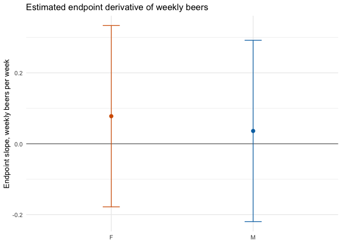

```r
weekly_slope_df <- as_tibble(emm_weekly_slope)

ggplot(weekly_slope_df, aes(sex, emmean, colour = sex)) +
  geom_hline(yintercept = 0, colour = "grey45") +
  geom_errorbar(aes(ymin = lower.CL, ymax = upper.CL), width = 0.12) +
  geom_point(size = 2.2) +
  scale_colour_manual(values = sex_cols, guide = "none") +
  labs(
    title = "Estimated endpoint derivative of weekly beers",
    x = NULL,
    y = "Endpoint slope, weekly beers per week"
  )
```

The Gaussian model can produce fitted values below zero for sparse count data, so this fit should be read as a functional-trajectory demonstration rather than as a full count model.

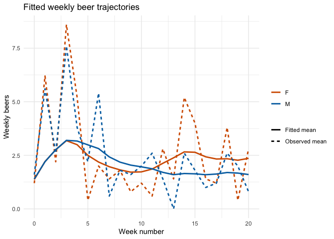

```r
weekly_fitted_curves <- beer_weekly_df |>
  arrange(curve, week_index) |>
  mutate(
    fitted = as.numeric(predict(fit_weekly, type = "response")),
    residual = as.numeric(residuals(fit_weekly))
  )

weekly_mean_observed <- weekly_fitted_curves |>
  group_by(sex, week_index) |>
  summarise(value = mean(weekly_beers), .groups = "drop") |>
  mutate(type = "Observed mean")

weekly_mean_fitted <- weekly_fitted_curves |>
  group_by(sex, week_index) |>
  summarise(value = mean(fitted), .groups = "drop") |>
  mutate(type = "Fitted mean")

weekly_mean_plot <- bind_rows(weekly_mean_observed, weekly_mean_fitted)

ggplot(weekly_mean_plot, aes(week_index, value, colour = sex, linetype = type)) +
  geom_line(linewidth = 1) +
  scale_colour_manual(values = sex_cols) +
  scale_x_continuous(breaks = seq(0, n_weeks - 1L, by = 5)) +
  labs(
    title = "Fitted weekly beer trajectories",
    x = "Week number",
    y = "Weekly beers",
    colour = NULL,
    linetype = NULL
  )
```

## Known Limitations

At the time of writing, user-specified grouped random effects are not part of the public modeling workflow. The practical supported pattern is to use the formula interface for ordinary fixed effects and to use `boundary_formula` for curve-level boundary-value regressions. The serial functional effect is handled internally through the operator-projection machinery.